# 210 Patient Summary Figures

Camilo Posso

10/04/2021

# Introduction

In this short report we collect a few figures exploring the functional, global, and phospho datasets we have for the large 210 patient experiment.

# Functional Data

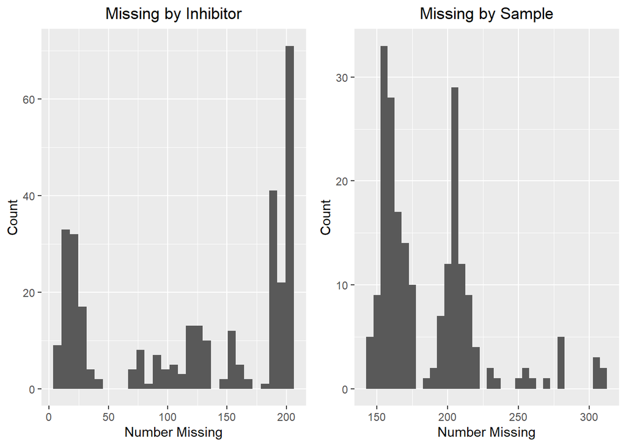

Next we plot a histogram of the AUC values themselves (Area under curve), coloring by FLT3 status and Specimen Type.

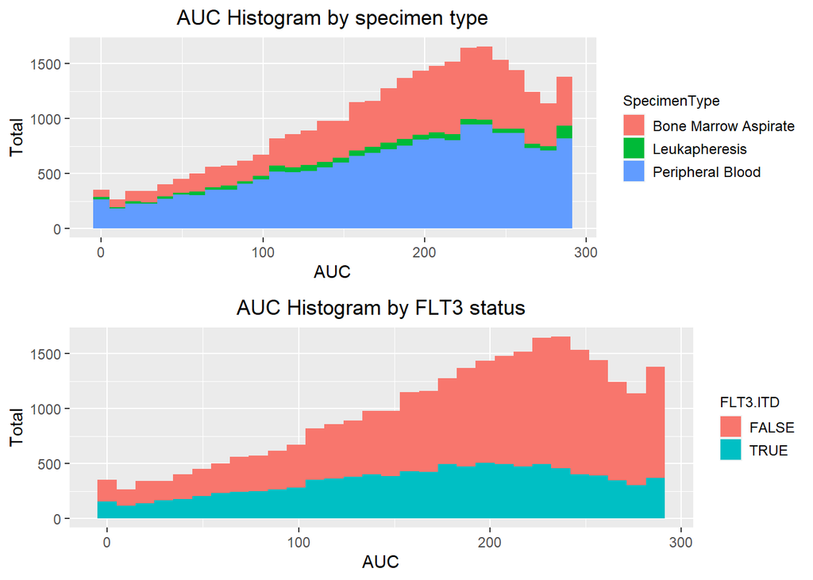

```r
layout <- as.matrix(c(1,2))
grid.arrange(grobs = list(p1,p2), layout_matrix = layout)
```

Below we have a heatmap of the AUC values. Note that we cluster the columns (samples) and rows (inhibitors) using correlation. Furthermore, in order to compute the distances required for clustering, we filter the Inhibitors in such a way that at least ~20 observations are used when computing these distances. We are thus left with 110 inhibitors and all 210 patients when making the heatmap.

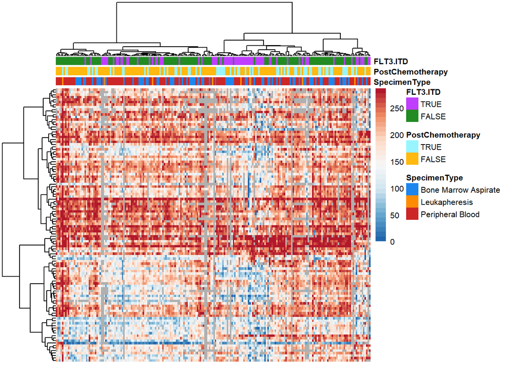

```r
pheatmap(functional.mat, scale = "none", annotation_col = ann.labels, annotation_colors = ann.colors,
         color = colorRampPalette(rev(brewer.pal(n = 7, name = "RdBu")))(32), fontsize = 8,
         clustering_distance_cols = "correlation", clustering_distance_rows = "correlation",
         clustering_method = "ward.D", cluster_rows = tree_row, cluster_cols = tree_col,
         show_rownames = F, show_colnames = F, na_col = "gray69")
```

# Global Data

Below we see a summary of the distribution of missing values in the global data.

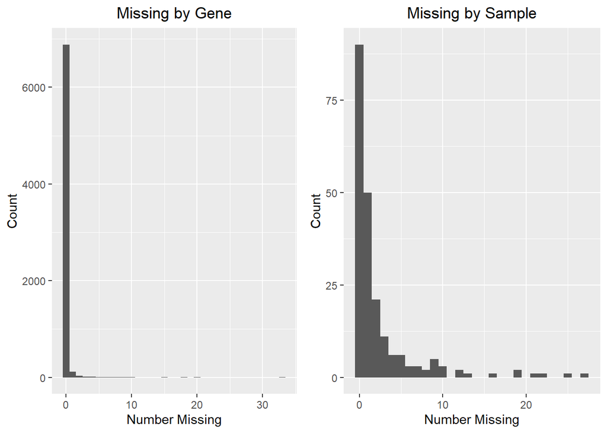

```r
grid.arrange(grobs = list(p1,p2), ncol = 2)
```

Finally, we show PCA plots by FLT3.ITD status, Specimen Type and Post Chemotherapy status.

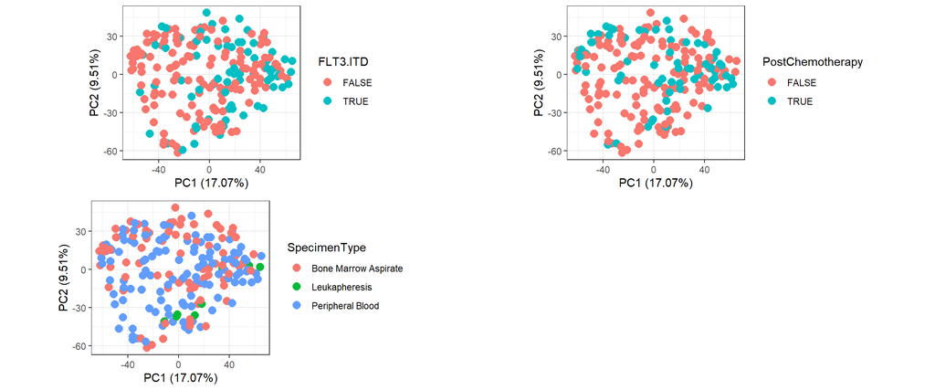

```r
grid.arrange(grobs = list(p1,p3,p2), ncol = 2)
```

# Phospho Data

Below we see a summary of the distribution of missing values in the phospho data.

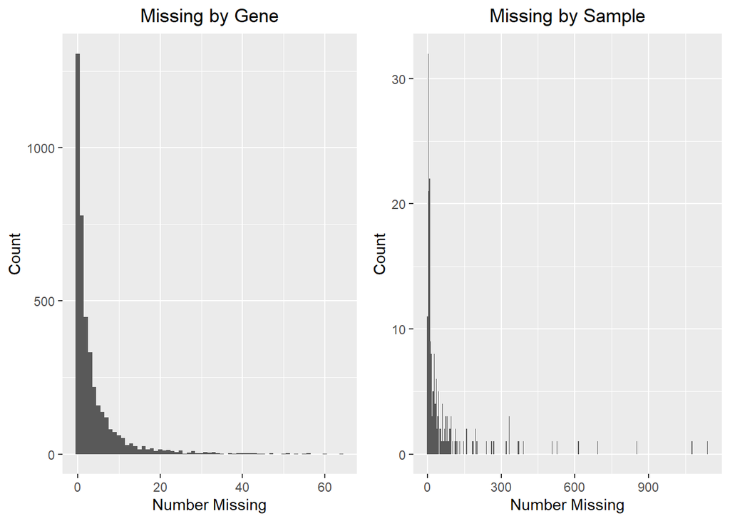

```r
grid.arrange(grobs = list(p1,p2), ncol = 2)
```

Finally, we show PCA plots by FLT3.ITD status, Specimen Type and Post Chemotherapy status.

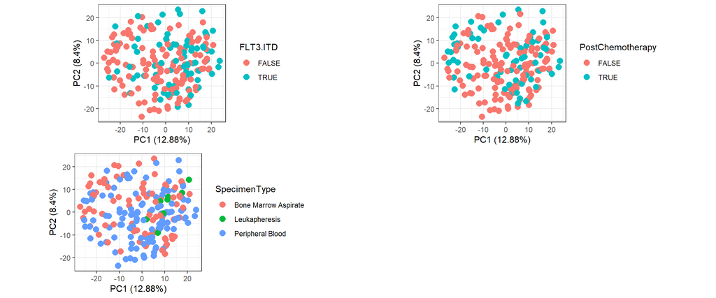

```r
grid.arrange(grobs = list(p1,p3,p2), ncol = 2)
```